# Homework 08

The former kernel-tuning question has moved to Homework 09.

Solutions for Questions 1 and 2 will be available after Monday, October 19, 2026. No solution can be provided for Question 3.

For Questions 1 and 2, use either R or Python.

## Question 1: Boundary and margin

Use `margin-geometry-20.csv` from the combined ZIP, which contains 20 observations with predictors $x_1,x_2$ and class labels $y\in\{-1,1\}$. Consider the score

$$f(x)=0.8x_1+0.6x_2.$$

Since $\|(0.8,0.6)\|_2=1$, the lines $f(x)=\pm1$ are each a distance 1 from the decision boundary $f(x)=0$.

1. Calculate the distance from every observation to the decision boundary and its functional margin $yf(x)$. In a table, report these values and whether each observation is inside, on, or beyond the margin for its class. Compare $yf(x)$ with 1 to make this distinction.
2. Plot the observations, the boundary $f(x)=0$, and the margin lines $f(x)=\pm1$. Distinguish the two classes and identify the observations inside the margin in your plot.
3. Report how many observations are inside, on, and beyond the margin. Which observations are misclassified by this decision rule?

Use the observation numbers supplied in the data. Set the $x_1$ axis to $[-3.2,3.2]$, set the $x_2$ axis to $[-3,3]$, and use an equal aspect ratio. Do not fit a new classifier for this question.

## Solution to Question 1

The coefficient vector is $\boldsymbol{\beta}=(0.8,0.6)^{\mathsf T}$, so its norm is

$$\|\boldsymbol{\beta}\|_2=\sqrt{0.8^2+0.6^2}=1.$$

Therefore, the perpendicular distance from an observation to the decision boundary is $|f(x)|$.

### (a)

```r
margin_data <- read.csv("C:/Users/melik/Documents/UIUC/courses/STAT432 - Zhu/homework/week-08/data/margin-geometry-20.csv")

margin_data$f <- 0.8 * margin_data$x1 + 0.6 * margin_data$x2
margin_data$distance <- abs(margin_data$f)
margin_data$functional_margin <- margin_data$y * margin_data$f

margin_data$margin_status <- ifelse(
  margin_data$functional_margin < 1,
  "inside",
  ifelse(margin_data$functional_margin == 1, "on", "beyond")
)

margin_table <- margin_data[
  c("observation", "x1", "x2", "y", "f", "distance",
    "functional_margin", "margin_status")
]

display_table <- margin_table[
  c("observation", "f", "distance", "functional_margin", "margin_status")
]
names(display_table) <- c(
  "Observation", "f(x)", "Distance", "y f(x)", "Position"
)
knitr::kable(display_table, digits = 2)
```

| Observation | f(x) | Distance | y f(x) | Position |
| --- | --- | --- | --- | --- |
| 1 | 1.00 | 1.00 | 1.00 | on |
| 2 | 1.35 | 1.35 | 1.35 | beyond |
| 3 | 1.50 | 1.50 | 1.50 | beyond |
| 4 | 1.70 | 1.70 | 1.70 | beyond |
| 5 | 1.90 | 1.90 | 1.90 | beyond |
| 6 | 2.20 | 2.20 | 2.20 | beyond |
| 7 | 2.40 | 2.40 | 2.40 | beyond |
| 8 | 0.64 | 0.64 | 0.64 | inside |
| 9 | 0.20 | 0.20 | 0.20 | inside |
| 10 | -0.20 | 0.20 | -0.20 | inside |
| 11 | -1.00 | 1.00 | 1.00 | on |
| 12 | -1.30 | 1.30 | 1.30 | beyond |
| 13 | -1.55 | 1.55 | 1.55 | beyond |
| 14 | -1.75 | 1.75 | 1.75 | beyond |
| 15 | -1.95 | 1.95 | 1.95 | beyond |
| 16 | -2.15 | 2.15 | 2.15 | beyond |
| 17 | -2.45 | 2.45 | 2.45 | beyond |
| 18 | -0.64 | 0.64 | 0.64 | inside |
| 19 | -0.24 | 0.24 | 0.24 | inside |
| 20 | 0.20 | 0.20 | -0.20 | inside |

An observation is inside the margin when $yf(x)<1$, on the margin when $yf(x)=1$, and beyond the margin when $yf(x)>1$.

### (b)

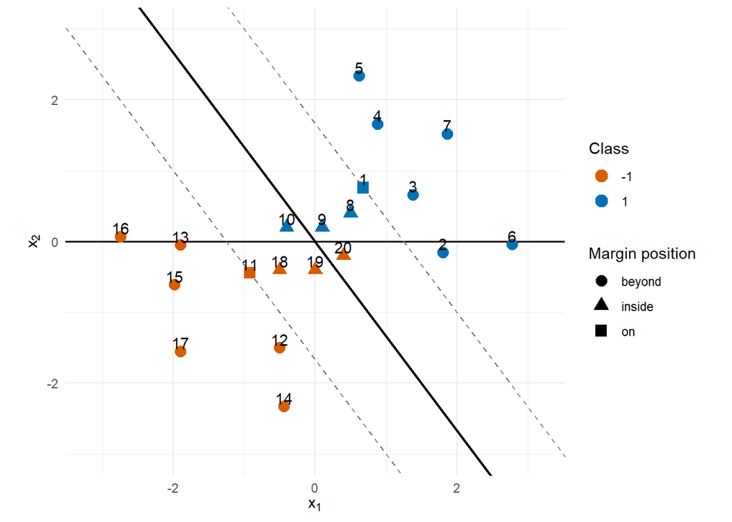

```r
library(ggplot2)
ggplot(margin_data, aes(x = x1, y = x2, color = factor(y))) +
  geom_hline(yintercept = 0, color = "black", linewidth = 0.6) +
  geom_abline(
    slope = -0.8 / 0.6, intercept = 0,
    color = "black", linewidth = 0.8
  ) +
  geom_abline(
    slope = -0.8 / 0.6, intercept = 1 / 0.6,
    color = "gray40", linetype = "dashed"
  ) +
  geom_abline(
    slope = -0.8 / 0.6, intercept = -1 / 0.6,
    color = "gray40", linetype = "dashed"
  ) +
  geom_point(
    aes(shape = margin_status, fill = factor(y)),
    size = 3, stroke = 1.1
  ) +
  geom_text(
    aes(label = observation),
    color = "black", nudge_y = 0.12, show.legend = FALSE
  ) +
  scale_color_manual(values = c("-1" = "#D55E00", "1" = "#0072B2")) +
  scale_fill_manual(values = c("-1" = "#D55E00", "1" = "#0072B2")) +
  coord_fixed(xlim = c(-3.2, 3.2), ylim = c(-3, 3)) +
  labs(
    x = expression(x[1]),
    y = expression(x[2]),
    color = "Class",
    fill = "Class",
    shape = "Margin position"
  ) +
  theme_minimal()
```

The solid diagonal line is the decision boundary $f(x)=0$. The two dashed parallel lines are the margin boundaries $f(x)=1$ and $f(x)=-1$. The following code reports the observations inside the margin:

```r
margin_data$observation[margin_data$functional_margin < 1]
```

```
[1]  8  9 10 18 19 20
```

### (c)

```r
margin_counts <- as.data.frame(table(margin_data$margin_status))
names(margin_counts) <- c("Position", "Number")
knitr::kable(margin_counts)
```

| Position | Number |
| --- | --- |
| beyond | 12 |
| inside | 6 |
| on | 2 |

```r
margin_data$predicted_class <- ifelse(margin_data$f >= 0, 1, -1)
misclassified <- subset(
  margin_data,
  predicted_class != y,
  select = c(observation, y, f, functional_margin, predicted_class)
)
knitr::kable(misclassified, digits = 2)
```

|  | observation | y | f | functional_margin | predicted_class |
| --- | --- | --- | --- | --- | --- |
| 10 | 10 | 1 | -0.2 | -0.2 | -1 |
| 20 | 20 | -1 | 0.2 | -0.2 | 1 |

The first table gives the counts for each margin position, and the second table identifies the observations misclassified by the decision rule.

## Question 2: Margin in four dimensions

Use `margin-geometry-4d.csv` from the combined ZIP, which contains 50 observations with four predictors and class labels $y\in\{-1,1\}$. Consider the linear score

$$f(\mathbf{x})=\beta_0+\mathbf{x}^{\mathsf T}\boldsymbol{\beta},
\qquad
\beta_0=-1,
\quad
\boldsymbol{\beta}=(1,2,-2,4)^{\mathsf T}.$$

1. Project the observations onto the direction of $\boldsymbol{\beta}$ and plot their positions on one axis. Distinguish the two classes and mark the decision boundary. Use the plot to calculate the geometric margin $M$, the distance from the boundary to the closest observation.
2. Express the same decision boundary using the SVM normalization in which the smallest functional margin $y_i f(\mathbf{x}_i)$ is set to 1. What are the corresponding values of $\boldsymbol{\beta}$ and $\beta_0$?

## Solution to Question 2

Let $\|\boldsymbol{\beta}\|$ denote the Euclidean norm of the coefficient vector. The signed projection of $\mathbf{x}$ onto the direction of $\boldsymbol{\beta}$ is

$$z=\frac{\mathbf{x}^{\mathsf T}\boldsymbol{\beta}}
{\|\boldsymbol{\beta}\|}.$$

The decision boundary satisfies $\mathbf{x}^{\mathsf T}\boldsymbol{\beta}=-\beta_0$, so its location on this projection axis is

$$z_0=\frac{-\beta_0}{\|\boldsymbol{\beta}\|}.$$

### (a)

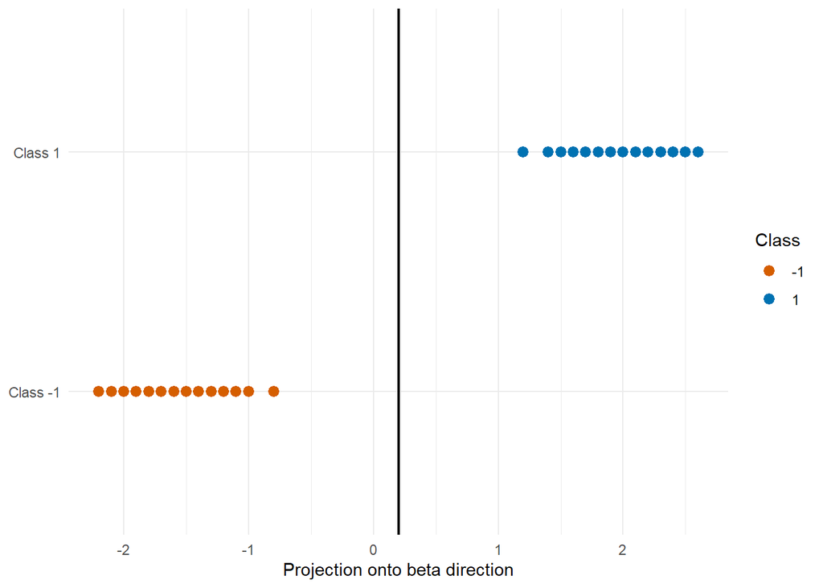

```r
margin_4d <- read.csv("C:/Users/melik/Documents/UIUC/courses/STAT432 - Zhu/homework/week-08/data/margin-geometry-4d.csv")

beta <- c(1, 2, -2, 4)
beta_0 <- -1
beta_norm <- sqrt(sum(beta^2))

margin_4d$score <- beta_0 + as.matrix(
  margin_4d[c("x1", "x2", "x3", "x4")]
) %*% beta
margin_4d$projection <- as.matrix(
  margin_4d[c("x1", "x2", "x3", "x4")]
) %*% beta / beta_norm
boundary_projection <- -beta_0 / beta_norm

margin_4d$distance_to_boundary <- abs(
  margin_4d$projection - boundary_projection
)
geometric_margin <- min(margin_4d$distance_to_boundary)
closest_observations <- margin_4d$observation[
  margin_4d$distance_to_boundary == geometric_margin
]

library(ggplot2)

ggplot(
  margin_4d,
  aes(x = projection, y = factor(y), color = factor(y))
) +
  geom_vline(xintercept = boundary_projection, linewidth = 0.8) +
  geom_point(size = 2.8) +
  scale_color_manual(values = c("-1" = "#D55E00", "1" = "#0072B2")) +
  scale_y_discrete(labels = c("-1" = "Class -1", "1" = "Class 1")) +
  labs(
    x = "Projection onto beta direction",
    y = NULL,
    color = "Class"
  ) +
  theme_minimal()
```

Here $\|\boldsymbol{\beta}\|=5$, and the decision boundary is at $z_0=-(-1)/5=0.2$. The closest projected observations are observations 4 and 33 from class 1, at $z=1.2$, and observations 15 and 36 from class $-1$, at $z=-0.8$. Therefore,

$$M=\min_i\left|z_i-z_0\right|=1.$$

### (b)

For the supplied coefficients, the functional margins are $y_i f(\mathbf{x}_i)$. The smallest functional margin in the data is 5, attained by observations 4, 15, 33, and 36. Dividing the score by 5 preserves its zero set while making the smallest functional margin equal to 1. Thus the SVM-normalized coefficients are

$$\boldsymbol{\beta}_{\mathrm{SVM}}
=\frac{1}{5}(1,2,-2,4)^{\mathsf T}
=(0.2,0.4,-0.4,0.8)^{\mathsf T},
\qquad
\beta_{0,\mathrm{SVM}}=\frac{-1}{5}=-0.2.$$

## Question 3: Peer review of a Homework 7 skill

The instructor’s GitHub account, **rqzhu-aide**, will open a **GitHub Issue** in the repository containing your Homework 7 submission. It will link to **one** assigned student’s repository.

1. **Use the skill.** Find the complete skill definition in the assigned student’s Homework 7 report. Copy it without changes into a local `SKILL.md` file in your own folder. You do not need to install it. Give your agent the path to the file and explicitly ask it to follow that skill while analyzing the `SAheart` data, using the response and predictor coding from Homework 7. Provide the necessary data information, but no additional preferences about methods, figures, model selection, or report style. Let the skill direct the analysis.

   Monitor the time, your token use, and your weekly quota while the agent works. If the run is taking too long or using your allowance too quickly, you may send a **steer message** asking the agent to finish immediately, or stop the run and summarize what you observed. A steer message redirects an agent while it is working; learn how to send one in your AI tool before starting.
2. **Write a peer review.** Read the student’s submitted report and what the skill produced in your run. Give a brief overall assessment, followed by **three major items the author could improve**. You may comment on any aspect of the skill or report. For each item, explain what you observed, why it matters, and what you recommend changing. If you stopped the run early, explain where and why. Write the review yourself, without AI assistance.
3. **Share your review.** Open a GitHub Issue in the assigned student’s Homework 7 repository containing your review. Copy the same review into your Homework 8 submission report and include a link to the GitHub Issue.

### Peer review

Overall, the analysis ran smoothly and produced a clean, well-organized summary. It included useful details about the data, coding, train-test split, cross-validation results, model selection, and final test performance. The results were easy to follow and the limitations were stated clearly.

The following are three major ways the report could be improved:

1. **Provide the required one-page PDF report.** The numerical results and supporting text were present and clearly written, but the required one-page report was not produced as a PDF.
2. **Add a figure showing the model comparison.** The report presented the cross-validation errors numerically, but it did not include the required plot with error bars. A visual comparison would make the small difference between LDA and QDA easier to interpret and would help communicate the uncertainty in the cross-validation estimates.
3. **Add a brief concluding paragraph.** The report explained the procedure and reported the results, but a short conclusion would make the main takeaway more explicit.

GitHub Issue link: https://github.com/willmeyer2/stat432-fall2026/issues/4#issue-5917330695